# Poor performance of Wald CIs for proportions

Author

Jacob Goldstein-Greenwood

Published

2025-04-22

Andersson, 2023, *The American Statistician*, “The Wald confidence interval for a binomial *p* as an illuminating ‘bad’ example.” DOI: 10.1080/00031305.2023.2183257.

> “The standard two-sided Wald interval for the binomial *p* is by now well known to be of low quality with respect to actual coverage and it ought to be stricken from all courses in mathematical statistics/statistics as the recommended interval to use. However, it still lingers on in quite a few textbooks.”

The Wald confidence interval (CI) for a proportion is erratic, often straying markedly from the nominal coverage rate. Received wisdom is that the interval’s performance decays as *p* drifts from 0.5 toward 0 or 1 and/or as *n* decreases. Brown et al. (2001, *Statistical Science*) note that it’s more accurate to characterize the Wald interval as being subject to “lucky” and “unlucky” (*p*, *n*) pairings. For example, they show that, surprisingly, the 95% Wald interval’s coverage is higher (and closer to 95%) for (*p* = 0.2, *n* = 30) than for (*p* = 0.2, *n* = 98).

I simulated data from binomial distributions at a range of (*p*, *n*) combinations and estimated 95% Wald CIs and 95% Wilson CIs for the resulting proportions. I repeated the process 2500 times for each (*p*, *n*) pairing. The coverage rates—the fraction of intervals of each type that captured *p* for each set of (*p*, *n*) values—are below:

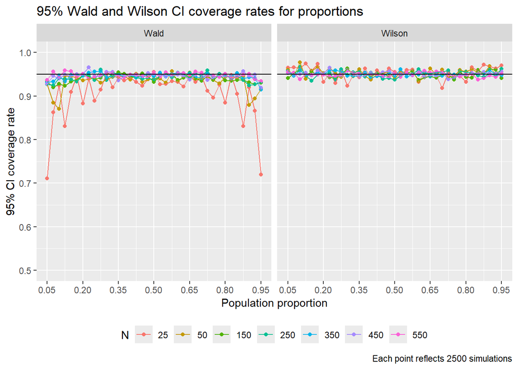

```r
library(ggplot2)

# Set simulation conditions
set.seed(999)
props <- seq(.05, .95, by = .025)
n <- c(25, seq(50, 550, by = 100))
sim_conditions <- expand.grid(props, n)
colnames(sim_conditions) <- c('prop', 'n')
res <- vector('list', nrow(sim_conditions))
reps <- 2500
z_975 <- qnorm(.975)

# Run
#   Formula reference for Wilson CI:
#   https://www.itl.nist.gov/div898/handbook/prc/section2/prc241.htm
for (i in 1:nrow(sim_conditions)) {
  res[[i]] <- replicate(reps, {
    draws <- rbinom(sim_conditions$n[i], 1, sim_conditions$prop[i])
    prop <- mean(draws)

    wald_CI_width <- z_975 * sqrt((prop*(1-prop)) / sim_conditions$n[i])
    wald_CI <- prop + c(-wald_CI_width, wald_CI_width)
    wald_captures <- ifelse(sim_conditions$prop[i] <= wald_CI[2] &&
                              sim_conditions$prop[i] >= wald_CI[1], T, F)

    wilson_CI_width <- z_975*sqrt((prop*(1-prop))/sim_conditions$n[i] +
                                    z_975^2/(4*sim_conditions$n[i]^2))
    wilson_CI <- (prop + z_975^2/(2*sim_conditions$n[i]) +
                    c(-wilson_CI_width, wilson_CI_width)) / (1 + z_975^2/sim_conditions$n[i])
    wilson_captures <- ifelse(sim_conditions$prop[i] <= wilson_CI[2] &&
                                sim_conditions$prop[i] >= wilson_CI[1], T, F)

    c('Wald' = wald_captures, 'Wilson' = wilson_captures)
  })
}

# Organize results
sim_conditions$coverage_Wald <- sapply(res, \(x) mean(x[1, ]))
sim_conditions$coverage_Wilson <- sapply(res, \(x) mean(x[2, ]))

d <- tidyr::pivot_longer(sim_conditions,
                         cols = c('coverage_Wald', 'coverage_Wilson'),
                         values_to = 'coverage',
                         names_to = 'method',
                         names_prefix = 'coverage_')

d$n <- as.factor(d$n)

# Plot
ggplot(d, aes(prop, coverage, color = n)) +
  geom_point() +
  geom_line() +
  facet_wrap(~method) +
  scale_x_continuous(breaks = seq(.05, .95, by = .15)) +
  ylim(.5, 1) +
  labs(x = 'Population proportion',
       y = '95% CI coverage rate',
       title = '95% Wald and Wilson CI coverage rates for proportions',
       color = 'N',
       caption = 'Each point reflects 2500 simulations') +
  theme(legend.position = 'bottom') +
  guides(color = guide_legend(nrow = 1)) +
  geom_hline(yintercept = .95)
```

The simulation results show, as noted by Brown et al. (2001) and Andersson (2023), that the Wald interval’s performance is jagged: It does not decrease monotonically as *p* approaches 0 or 1, nor does it decrease monotonically as *n* decreases. That one can find occasional “lucky” (*p*, *n*) combinations does not, though, make the picture rosy: The Wald CI has broadly decayed coverage, and many more of the Wald CI coverage rates calculated here fall below 95% compared to the Wilson CI coverage rates:

```r
under_coverage_prop <- aggregate(d$coverage,
                                 list(d$method),
                                 \(x) round(mean(x < .95), digits = 3))

knitr::kable(under_coverage_prop,
             col.names = c('CI type', 'Proportion of coverage rates < .95'))
```

| CI type | Proportion of coverage rates < .95 |
| --- | --- |
| Wald | 0.792 |
| Wilson | 0.456 |

The Wilson interval is not alone as a (preferable) alternative to the Wald interval for proportions, but it is a fair go-to. It received complimentary examinations in Andersson (2023) and Brown et al. (2001), and it is Harrell’s [recommended (frequentist) interval](https://hbiostat.org/bbr/htest#frequentist-methods) as of April 2025 in *Biostatistics for Biomedical Research*.